# Lab 3

## Objective

To investigae the spetral properties of waeveforms and understand the impact of amplitude modulations

## Fourier transform and spectral analysis

Establish communication channel, W1 - generate sinusoidal waveform (1kHz, 1V, 0V offset), Read via CH1

### Communication Channel set up

```python
# communication channel setup
import serial
import serial.tools.list_ports
import numpy as np
import plotly.graph_objs as go

VID = 61525
PID = 38912

device = None

ports = serial.tools.list_ports.comports()
for p in ports:
    if p.vid == VID and p.pid == PID:
        try:
            device = serial.Serial(p.device)
        except serial.SerialException:
            print('Reconnect the controller unit.')

if device is None:
    raise Exception('No suitable device detected.')
```

### Waveform generation

```python
# waveform generation
ns = 64
freq = 1000
amp = 1
offset = 0
cmd_gensin = 's100'
cmd_gensin += str(ns).zfill(3) + str(freq).zfill(7) + str(int(amp*100)).zfill(4) + str(int(offset*100)).zfill(4) + '\r'
device.write(bytes(cmd_gensin, 'utf-8'))
```

```
23
```

### Waveform detection and plotting

```python
# waveform detection and plotting
fs = 20000
c2 = 0
gain1 = 138
dco1 = 130
c1 = 0
gain2 = 138
dco2 = 130
cmd_readosc = 'm1' + str(fs).zfill(6) + str(c1) + str(gain1).zfill(3) + str(dco1).zfill(3) + str(c2) + str(gain2).zfill(3) + str(dco2).zfill(3) + '\r'
bytedata = bytearray(4000)
device.reset_input_buffer()
device.write(bytes(cmd_readosc, 'utf-8'))
device.readline()
device.readinto(bytedata)
data = np.frombuffer(bytedata, dtype='uint16').reshape((2, 1000))
t = np.arange(1000)/fs
sig = 2*(data[0, :] - np.mean(data[0, :]))/np.ptp(data[0, :]) # adjust
fig = go.Figure()
fig.add_trace(go.Scatter(x=t*1e3, y=sig))
fig.update_layout(xaxis_title='Time (ms)', yaxis_title='Voltage (V)')
```

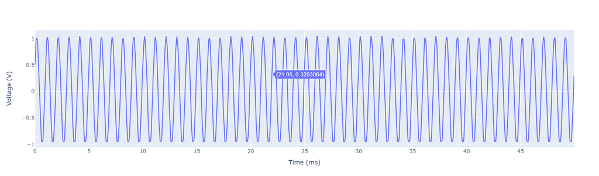

### Plotting of sinusoidal voltage signal taken from CH1

rfft() - used to compute the fast Fourier transform for a real number array. Returns an array of complex numbers where thier magnitude and phase represent the amplitude and phase of the corresponding frequency component.

rfftfreq() - create a frequency array based on the sampling frequency and the number of samples

abs() - functions for magnitutdes.

```python
f = np.fft.rfftfreq(len(t), d=1/fs)  # frequency array
spec = np.abs(np.fft.rfft(sig))/len(f) # spectral amplitudes
fig = go.Figure()
fig.add_trace(go.Scatter(x=f*1e-3, y=spec))
fig.update_layout(xaxis_title='Frequency (kHz)', yaxis_title='Amplitude (a.u.)')
```

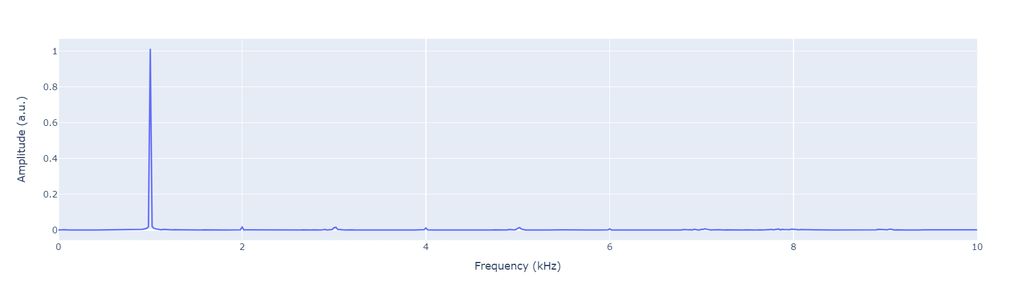

## Generating triangular (W1) and sawtooth (W2) waveform

### Generating Triangular Waveform (W1)

```python
# waveform generation
ns = 64             #samples per cycle
freq = 1000         #freq
amp = 1             #amplitude
offset = 0          #dc offset
cmd_gensin = 's110' #triangular waveform at W1
cmd_gensin += str(ns).zfill(3) + str(freq).zfill(7) + str(int(amp*100)).zfill(4) + str(int(offset*100)).zfill(4) + '\r'
device.write(bytes(cmd_gensin, 'utf-8'))
```

```
23
```

### Plotting of voltage signal taken from CH1

```python
# waveform detection and plotting
fs = 20000
c2 = 0
gain1 = 138
dco1 = 130
c1 = 0
gain2 = 138
dco2 = 130
cmd_readosc = 'm1' + str(fs).zfill(6) + str(c1) + str(gain1).zfill(3) + str(dco1).zfill(3) + str(c2) + str(gain2).zfill(3) + str(dco2).zfill(3) + '\r'
bytedata = bytearray(4000)
device.reset_input_buffer()
device.write(bytes(cmd_readosc, 'utf-8'))
device.readline()
device.readinto(bytedata)
data = np.frombuffer(bytedata, dtype='uint16').reshape((2, 1000))
t = np.arange(1000)/fs
sig = 2*(data[0, :] - np.mean(data[0, :]))/np.ptp(data[0, :]) # adjust
fig = go.Figure()
fig.add_trace(go.Scatter(x=t*1e3, y=sig))
fig.update_layout(xaxis_title='Time (ms)', yaxis_title='Voltage (V)')
```

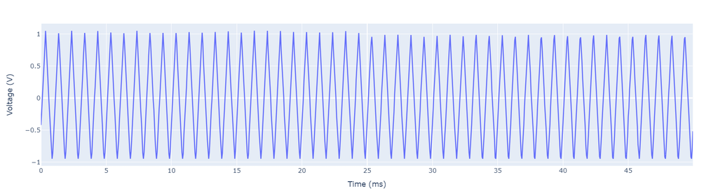

```python
f = np.fft.rfftfreq(len(t), d=1/fs)  # frequency array
spec = np.abs(np.fft.rfft(sig))/len(f) # spectral amplitudes
fig = go.Figure()
fig.add_trace(go.Scatter(x=f*1e-3, y=spec))
fig.update_layout(xaxis_title='Frequency (kHz)', yaxis_title='Amplitude (a.u.)')
```

[output not shown]

### Generating Sawtooth Waveform (W2)

```python
# waveform generation
ns = 64             #samples per cycle
freq = 1000         #freq
amp = 1             #amplitude
offset = 0          #dc offset
cmd_gensin = 's211' #sawtooth waveform at W2
cmd_gensin += str(ns).zfill(3) + str(freq).zfill(7) + str(int(amp*100)).zfill(4) + str(int(offset*100)).zfill(4) + '\r'
device.write(bytes(cmd_gensin, 'utf-8'))
```

```
23
```

```python
bytedata = bytearray(4000)
device.reset_input_buffer()
device.write(bytes(cmd_readosc, 'utf-8'))
device.readline()
device.readinto(bytedata)
data = np.frombuffer(bytedata, dtype='uint16').reshape((2, 1000))
t = np.arange(1000)/fs
sig = 2*(data[1, :] - np.mean(data[1, :]))/np.ptp(data[1, :]) # adjust
fig = go.Figure()
fig.add_trace(go.Scatter(x=t*1e3, y=sig))
fig.update_layout(xaxis_title='Time (ms)', yaxis_title='Voltage (V)')
```

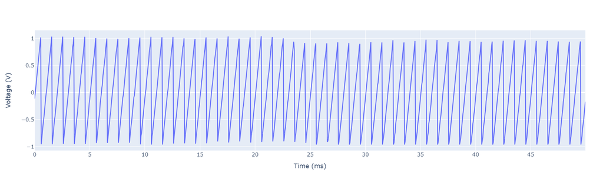

```python
f = np.fft.rfftfreq(len(t), d=1/fs)  # frequency array
spec = np.abs(np.fft.rfft(sig))/len(f) # spectral amplitudes
fig = go.Figure()
fig.add_trace(go.Scatter(x=f*1e-3, y=spec))
fig.update_layout(xaxis_title='Frequency (kHz)', yaxis_title='Amplitude (a.u.)')
```

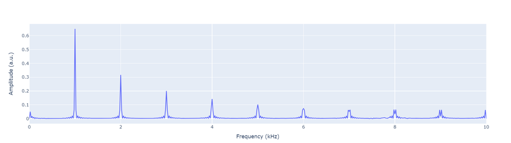

## Similarities and Differences of Sinusoidal, Triangular and Sawtooth waveform spectra

**Similarities**

- All waveforms are periodic and have fundamental frequency

**Differences**

*Sinusoidal*

- Single peak at 1kHZ (Fundamental Frequency)
- No harmonic present in a pure sinusoidal waveform

*Triangular*

- The triangular waveform has odd harmonics that decrease in magnitude at a rate of 1/n², where n is the harmonic number.
- Its spectrum consists of the fundamental frequency and odd harmonics with decreasing amplitudes.

*Sawtooth*

- Unlike the triangular waveform, the sawtooth waveform includes both odd and even harmonics.
- Its spectrum consists of the fundamental frequency and all integer harmonics, both odd and even, with decreasing amplitudes as the harmonic number increases.

## Ammplitude modulation and its influence on spectrum

### Generating Sinusoidal Waveform

```python
cmd_gensin = 's100'
cmd_gensin += str(ns).zfill(3) + str(freq).zfill(7) + str(int(amp*100)).zfill(4) + str(int(offset*100)).zfill(4) + '\r'
device.write(bytes(cmd_gensin, 'utf-8'))
```

```
23
```

### Detection at CH1

```python
# waveform detection
device.reset_input_buffer()
device.write(bytes(cmd_readosc, 'utf-8'))
device.readline()
device.readinto(bytedata)
data=np.frombuffer(bytedata, dtype='uint16').reshape((2, 1000))
t = np.arange(1000)/fs
sig = 2*(data[0, :] - np.mean(data[0, :]))/np.ptp(data[0, :])
```

### Amplitude Modulation

Modulation Freq = 100Hz

Modulation Depth = 0.5

```python
# amplitude modulation
mod_freq = 100
mod_depth = 0.5
mod = sig*(1 + mod_depth*np.sin(2*np.pi*mod_freq*t))
fig = go.Figure()
fig.add_trace(go.Scatter(x=t*1e3, y=mod))
fig.update_layout(xaxis_title='Time (ms)', yaxis_title='Voltage (a.u.)')
```

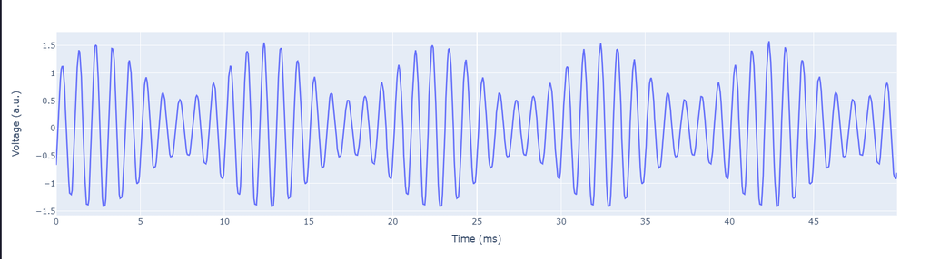

### Spectral Analysis

```python
# spectral analysis
spec_mod = abs(np.fft.rfft(mod))/len(f)
fig = go.Figure()
fig.add_trace(go.Scatter(x=f*1e-3, y=spec_mod))
fig.update_layout(xaxis_title='Frequency (kHz)', yaxis_title='Amplitude (a.u.)')
```

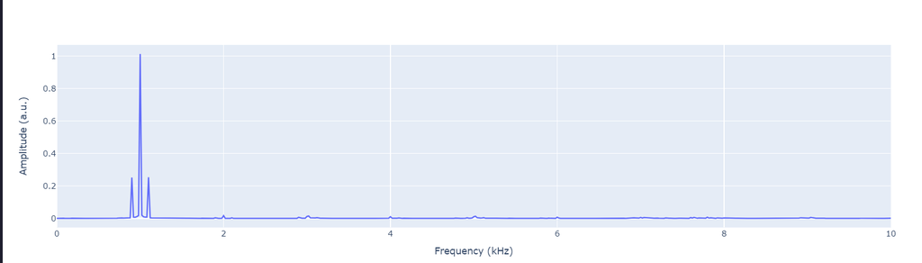

### Change in modulation freq and depth

```python
mod_freq = 0    #frequency = 0Hz
mod_depth = 0.5
mod = sig*(1 + mod_depth*np.sin(2*np.pi*mod_freq*t))
fig = go.Figure()
fig.add_trace(go.Scatter(x=t*1e3, y=mod))
fig.update_layout(xaxis_title='Time (ms)', yaxis_title='Voltage (a.u.)')
# spectral analysis
spec_mod = abs(np.fft.rfft(mod))/len(f)
fig = go.Figure()
fig.add_trace(go.Scatter(x=f*1e-3, y=spec_mod))
fig.update_layout(xaxis_title='Frequency (kHz)', yaxis_title='Amplitude (a.u.)')
```

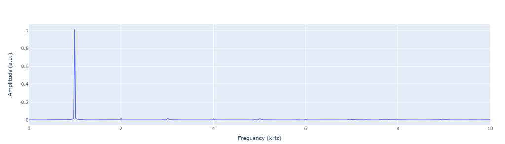

```python
mod_freq = 200   #frequency = 200Hz
mod_depth = 0.5
mod = sig*(1 + mod_depth*np.sin(2*np.pi*mod_freq*t))
fig = go.Figure()
fig.add_trace(go.Scatter(x=t*1e3, y=mod))
fig.update_layout(xaxis_title='Time (ms)', yaxis_title='Voltage (a.u.)')
# spectral analysis
spec_mod = abs(np.fft.rfft(mod))/len(f)
fig = go.Figure()
fig.add_trace(go.Scatter(x=f*1e-3, y=spec_mod))
fig.update_layout(xaxis_title='Frequency (kHz)', yaxis_title='Amplitude (a.u.)')
```

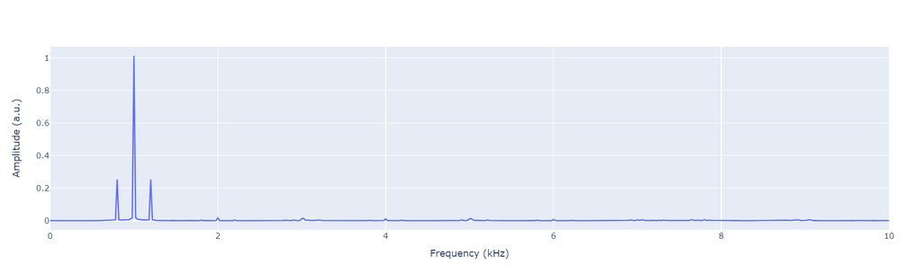

```python
mod_freq = 100    #frequency = 100Hz
mod_depth = 1   #depth = 1
mod = sig*(1 + mod_depth*np.sin(2*np.pi*mod_freq*t))
fig = go.Figure()
fig.add_trace(go.Scatter(x=t*1e3, y=mod))
fig.update_layout(xaxis_title='Time (ms)', yaxis_title='Voltage (a.u.)')
# spectral analysis
spec_mod = abs(np.fft.rfft(mod))/len(f)
fig = go.Figure()
fig.add_trace(go.Scatter(x=f*1e-3, y=spec_mod))
fig.update_layout(xaxis_title='Frequency (kHz)', yaxis_title='Amplitude (a.u.)')
```

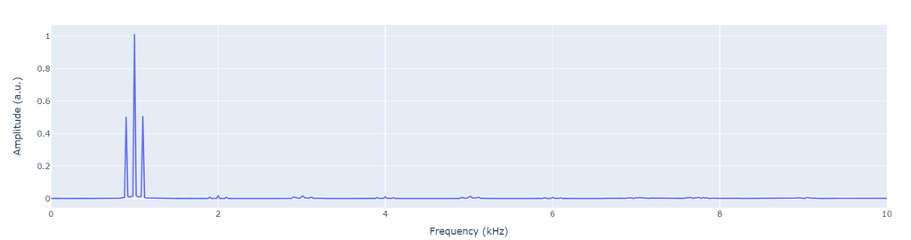

```python
mod_freq = 100   #frequency = 100Hz
mod_depth = 0    #depth = 0
mod = sig*(1 + mod_depth*np.sin(2*np.pi*mod_freq*t))
fig = go.Figure()
fig.add_trace(go.Scatter(x=t*1e3, y=mod))
fig.update_layout(xaxis_title='Time (ms)', yaxis_title='Voltage (a.u.)')
# spectral analysis
spec_mod = abs(np.fft.rfft(mod))/len(f)
fig = go.Figure()
fig.add_trace(go.Scatter(x=f*1e-3, y=spec_mod))
fig.update_layout(xaxis_title='Frequency (kHz)', yaxis_title='Amplitude (a.u.)')
```

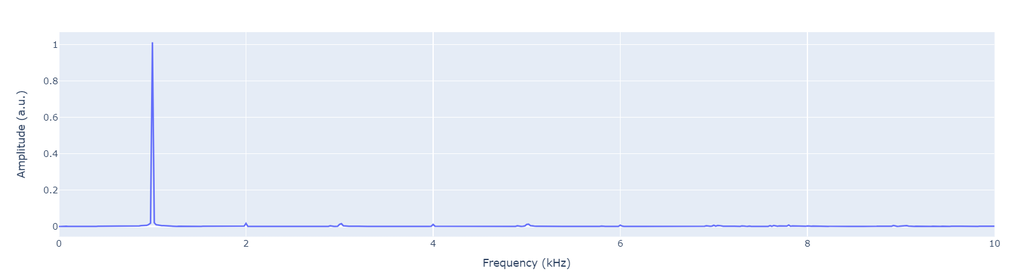

#### Observation in the effects of Modulation Frequency and Modulation Depth

*Modulation Frequency*

- Higher frequency:
  - broader bandwidth of modulated signal resulting in side bands further apart in the spectra
- Lower Frequency:
  - Lower modulation frequencies concentrate the sidebands closer to the carrier frequency

*Modulation Depth*

- Increasing the modulation depth increases the amplitude of the sidebands relative to the carrier.
  - This results in a more pronounced presence of the sidebands in the spectrum.
- At very high modulation depths, the modulation signal can distort the carrier waveform, leading to over-modulation effects and distortion in the demodulated signal.

To summarise, both modulation frequency and modulation depth influence the spectral properties of an AM signal. The modulation frequency regulates the spacing and distribution of the sidebands, whilst the modulation depth controls the relative amplitudes of the carrier and sideband. Balancing these factors is critical for efficient spectrum consumption and accurate signal reproduction in AM systems.